# Predicción de precios de las casas en Boston

Técnicas para ‘Big Data’ en Economía - Curso 2025/26  
Universidad de Alicante

Autor/a

Afiliación

Pedro Albarrán

Dpto. de Fundamentos del Análisis Económico. Universidad de Alicante

# Introducción

## Comentario General

Este documento debe entenderse como **un ejemplo**, no *la* guía única para el proyecto.

1. Aquí muestro algunas cosas que en vuestros trabajos probablemente NO queréis mostrar. Por ejemplo, he incluido la opción de que se muestre o se oculte el código de todo lo que he hecho, pero vosotros debéis pensar qué y cuándo queréis mostrar algo. También muestro algunos resultados que, como se ha discutido en clase, probablemente tampoco queráis mostrar (o no de la misma manera).
2. He omitido muchos detalles de algunas fases del trabajo que ya se han ido comentando y trabajando en clase (características de los datos, procedimientos, tablas con encabezados adecuados, gráficos con ejes correctamente nombrados, comentario de resultados, etc.)
3. Cada conjunto de datos es diferente y cada análisis es diferente. Se requiere un tratamiento distinto de los datos: (eliminar o imputar valores ausentes, transformar variables, agrupar categorías, discretizar, etc.), diferentes algoritmos y especificaciones (combinaciones de variables a incluir y sus transformaciones). De hecho, **se espera** que probéis distintas opciones y discutáis los resultados.

En resumen, este ejemplo incluye pruebas, gráficos y tablas que vosotros no incluiréis. También deberéis probar otras que aquí no he probado. Pero también se espera discusiones algo más detalladas (sin ser excesivas).

## Introducción y Objetivos

En este trabajo, se analizará un conjunto de datos con información sobre precios y otros atributos de una muestra de viviendas en Boston. Por un lado, el objetivo es examinar la influencia de varios atributos del vecindario en los precios de la vivienda, en un intento por descubrir las variables explicativas más adecuadas. Por otro lado, la construcción de un modelo de predicción permitirá determinar el valor por el que se puede poner en el mercado una vivienda o detectar si alguna está infravalorada o sobrevalorada dadas sus características.

El objetivo del trabajo es un elemento importante que debéis desarrollar adecuadamente. Todo el análisis y comentarios posteriores deben estar orientados a responder a las preguntas planteados por los objetivos.

# Datos

En este trabajo vamos a utilizar un conjunto de datos, “The Boston Housing Price”, derivados de la información recopilada por el Servicio de Censos de los Estados Unidos sobre las viviendas en el área de Boston (Massachusetts). Podemos encontrar algunos detalles adicionales sobre estos datos [aquí](https://www.cs.toronto.edu/~delve/data/boston/bostonDetail.html). Los datos pueden obtenerse desde esa misma página, pero por sencillez los leemos en formato de valores separados por comas (CSV) desde [aquí](https://raw.githubusercontent.com/selva86/datasets/master/BostonHousing.csv).

Los datos tienen 506 observaciones y 14 variables. (NOTA: NO está claro que queráis mostrar este código.)

```r
dim(Boston)
```

[1] 506 14

Una descripción completa los atributos disponibles puede encontrarse en Apéndice A. Estos datos fueron originalmente utilizados en un estudio sobre el impacto de la contaminación del aire (utilizando las concentraciones de óxido de nitrógeno). En este trabajo, consideramos el efecto de otras características de la zona donde se encuentra la casa como la proximidad al río Charles, la distancia a los principales centros de empleo, la calidad de las escuelas (medida por la ratio de número de alumnos por maestro) y los niveles de delincuencia. Nuestra variable de interés para predecir es el valor mediano del precio de la vivienda en mil dólares (denotado por MEDV). Notad que nos centramos en las viviendas ocupadas por sus propietarios, es decir, consideramos que el valor de las casas destinadas al alquiler se determina según un proceso diferente.

# Exploración Inicial

Debemos considerar si los datos están listos para trabajar o requieren algún tipo de limpieza, ordenación o transformación. En primer lugar, comprobamos si el tipo de datos de cada variable es el adecuado. En este caso, todas las variables son numéricas, lo cual se corresponde con la información cuantitativa de la mayoría de ellas. La variable que nos dice si la zona de la casa está cerca del río es una variable binaria, es decir, aporta información cualitativa. En este caso, no es crucial convertirla en un factor (en los modelos y para otras cuestiones, convertimos los factores en variables binarias). En otros casos, podemos necesitar convertir más variables con información cualitativa a factores o eliminar variables de tipo carácter o con información que no podamos procesar. NOTA: para esto habremos comprobado el tipo de cada variable, habremos mirado los valores y contrastado con la información que según su descripción debería tener. Utilizaríamos un código como el siguiente, aunque probablemente NO queráis incluir en el documento ni lo uno ni lo otro.

```r
glimpse(Boston)
```

```
Rows: 506
Columns: 14
$ crim    <dbl> 0.00632, 0.02731, 0.02729, 0.03237, 0.06905, 0.02985, 0.08829,…
$ zn      <dbl> 18.0, 0.0, 0.0, 0.0, 0.0, 0.0, 12.5, 12.5, 12.5, 12.5, 12.5, 1…
$ indus   <dbl> 2.31, 7.07, 7.07, 2.18, 2.18, 2.18, 7.87, 7.87, 7.87, 7.87, 7.…
$ chas    <dbl> 0, 0, 0, 0, 0, 0, 0, 0, 0, 0, 0, 0, 0, 0, 0, 0, 0, 0, 0, 0, 0,…
$ nox     <dbl> 0.538, 0.469, 0.469, 0.458, 0.458, 0.458, 0.524, 0.524, 0.524,…
$ rm      <dbl> 6.575, 6.421, 7.185, 6.998, 7.147, 6.430, 6.012, 6.172, 5.631,…
$ age     <dbl> 65.2, 78.9, 61.1, 45.8, 54.2, 58.7, 66.6, 96.1, 100.0, 85.9, 9…
$ dis     <dbl> 4.0900, 4.9671, 4.9671, 6.0622, 6.0622, 6.0622, 5.5605, 5.9505…
$ rad     <dbl> 1, 2, 2, 3, 3, 3, 5, 5, 5, 5, 5, 5, 5, 4, 4, 4, 4, 4, 4, 4, 4,…
$ tax     <dbl> 296, 242, 242, 222, 222, 222, 311, 311, 311, 311, 311, 311, 31…
$ ptratio <dbl> 15.3, 17.8, 17.8, 18.7, 18.7, 18.7, 15.2, 15.2, 15.2, 15.2, 15…
$ b       <dbl> 396.90, 396.90, 392.83, 394.63, 396.90, 394.12, 395.60, 396.90…
$ lstat   <dbl> 4.98, 9.14, 4.03, 2.94, 5.33, 5.21, 12.43, 19.15, 29.93, 17.10…
$ medv    <dbl> 24.0, 21.6, 34.7, 33.4, 36.2, 28.7, 22.9, 27.1, 16.5, 18.9, 15…
```

```r
head(Boston) |> kbl() |> kable_paper("hover")
```

| crim | zn | indus | chas | nox | rm | age | dis | rad | tax | ptratio | b | lstat | medv |
| --- | --- | --- | --- | --- | --- | --- | --- | --- | --- | --- | --- | --- | --- |
| 0.00632 | 18 | 2.31 | 0 | 0.538 | 6.575 | 65.2 | 4.0900 | 1 | 296 | 15.3 | 396.90 | 4.98 | 24.0 |
| 0.02731 | 0 | 7.07 | 0 | 0.469 | 6.421 | 78.9 | 4.9671 | 2 | 242 | 17.8 | 396.90 | 9.14 | 21.6 |
| 0.02729 | 0 | 7.07 | 0 | 0.469 | 7.185 | 61.1 | 4.9671 | 2 | 242 | 17.8 | 392.83 | 4.03 | 34.7 |
| 0.03237 | 0 | 2.18 | 0 | 0.458 | 6.998 | 45.8 | 6.0622 | 3 | 222 | 18.7 | 394.63 | 2.94 | 33.4 |
| 0.06905 | 0 | 2.18 | 0 | 0.458 | 7.147 | 54.2 | 6.0622 | 3 | 222 | 18.7 | 396.90 | 5.33 | 36.2 |
| 0.02985 | 0 | 2.18 | 0 | 0.458 | 6.430 | 58.7 | 6.0622 | 3 | 222 | 18.7 | 394.12 | 5.21 | 28.7 |

```r
Boston <- Boston |> mutate(chas = factor(chas,
                         levels=c(0,1), labels = c("No", "Yes")))
```

(NOTA: los nombres de las columnas y de las filas/variables son “mejorables”: si el documento está en castellano las columnas no deberían tener nombres en inglés y sería preferible que apareciera un nombre más descriptivo de las variables. Pero no voy a exigir esto en el plazo que tenemos. Eso sí, al menos que en algún sitio aparezca la descripción completa del nombre abreviado de las variables, como hago aquí con el Apéndice A.)

# Análisis Exploratorio y Visualización de los datos

La siguiente fase consiste en analizar la distribución de valores de cada variable (análisis de variación) y las posibles relaciones entre ellas (análisis de covariación). Esto nos puede llevar a realizar limpieza adicional de los datos (en particular, relacionada con valores ausentes y puede que atípicos) o transformaciones de los datos (como tomar logaritmos o discretizar alguna variable). También podemos encontrar características de los datos que sean de interés por sí mismas como para especificar los modelos. Para este análisis nos podemos ayudar en bibliotecas que realizan algunas de las tareas de forma automatizada. PERO recordad que NO queremos en general mostrar la salida directa de estos paquetes, sino que la utilizaremos para aprender nosotros y luego mostrar aquello que consideremos más interesante.

Por ejemplo, usando la biblioteca `skimr` podemos ver

```r
skim(Boston)
```

Data summary

| Name | Boston |
| --- | --- |
| Number of rows | 506 |
| Number of columns | 14 |
| _______________________ |  |
| Column type frequency: |  |
| factor | 1 |
| numeric | 13 |
| ________________________ |  |
| Group variables | None |

**Variable type: factor**

| skim_variable | n_missing | complete_rate | ordered | n_unique | top_counts |
| --- | --- | --- | --- | --- | --- |
| chas | 0 | 1 | FALSE | 2 | No: 471, Yes: 35 |

**Variable type: numeric**

| skim_variable | n_missing | complete_rate | mean | sd | p0 | p25 | p50 | p75 | p100 | hist |
| --- | --- | --- | --- | --- | --- | --- | --- | --- | --- | --- |
| crim | 0 | 1 | 3.61 | 8.60 | 0.01 | 0.08 | 0.26 | 3.68 | 88.98 | ▇▁▁▁▁ |
| zn | 0 | 1 | 11.36 | 23.32 | 0.00 | 0.00 | 0.00 | 12.50 | 100.00 | ▇▁▁▁▁ |
| indus | 0 | 1 | 11.14 | 6.86 | 0.46 | 5.19 | 9.69 | 18.10 | 27.74 | ▇▆▁▇▁ |
| nox | 0 | 1 | 0.55 | 0.12 | 0.38 | 0.45 | 0.54 | 0.62 | 0.87 | ▇▇▆▅▁ |
| rm | 0 | 1 | 6.28 | 0.70 | 3.56 | 5.89 | 6.21 | 6.62 | 8.78 | ▁▂▇▂▁ |
| age | 0 | 1 | 68.57 | 28.15 | 2.90 | 45.02 | 77.50 | 94.07 | 100.00 | ▂▂▂▃▇ |
| dis | 0 | 1 | 3.80 | 2.11 | 1.13 | 2.10 | 3.21 | 5.19 | 12.13 | ▇▅▂▁▁ |
| rad | 0 | 1 | 9.55 | 8.71 | 1.00 | 4.00 | 5.00 | 24.00 | 24.00 | ▇▂▁▁▃ |
| tax | 0 | 1 | 408.24 | 168.54 | 187.00 | 279.00 | 330.00 | 666.00 | 711.00 | ▇▇▃▁▇ |
| ptratio | 0 | 1 | 18.46 | 2.16 | 12.60 | 17.40 | 19.05 | 20.20 | 22.00 | ▁▃▅▅▇ |
| b | 0 | 1 | 356.67 | 91.29 | 0.32 | 375.38 | 391.44 | 396.22 | 396.90 | ▁▁▁▁▇ |
| lstat | 0 | 1 | 12.65 | 7.14 | 1.73 | 6.95 | 11.36 | 16.96 | 37.97 | ▇▇▅▂▁ |
| medv | 0 | 1 | 22.53 | 9.20 | 5.00 | 17.02 | 21.20 | 25.00 | 50.00 | ▂▇▅▁▁ |

o usando `dlookr`

```r
Boston |>
  describe() |>
  select(described_variables:kurtosis) |>
  kbl(digits = 2) |> kable_paper("hover")
```

| described_variables | n | na | mean | sd | se_mean | IQR | skewness | kurtosis |
| --- | --- | --- | --- | --- | --- | --- | --- | --- |
| crim | 506 | 0 | 3.61 | 8.60 | 0.38 | 3.60 | 5.22 | 37.13 |
| zn | 506 | 0 | 11.36 | 23.32 | 1.04 | 12.50 | 2.23 | 4.03 |
| indus | 506 | 0 | 11.14 | 6.86 | 0.30 | 12.91 | 0.30 | -1.23 |
| nox | 506 | 0 | 0.55 | 0.12 | 0.01 | 0.17 | 0.73 | -0.06 |
| rm | 506 | 0 | 6.28 | 0.70 | 0.03 | 0.74 | 0.40 | 1.89 |
| age | 506 | 0 | 68.57 | 28.15 | 1.25 | 49.05 | -0.60 | -0.97 |
| dis | 506 | 0 | 3.80 | 2.11 | 0.09 | 3.09 | 1.01 | 0.49 |
| rad | 506 | 0 | 9.55 | 8.71 | 0.39 | 20.00 | 1.00 | -0.87 |
| tax | 506 | 0 | 408.24 | 168.54 | 7.49 | 387.00 | 0.67 | -1.14 |
| ptratio | 506 | 0 | 18.46 | 2.16 | 0.10 | 2.80 | -0.80 | -0.29 |
| b | 506 | 0 | 356.67 | 91.29 | 4.06 | 20.85 | -2.89 | 7.23 |
| lstat | 506 | 0 | 12.65 | 7.14 | 0.32 | 10.01 | 0.91 | 0.49 |
| medv | 506 | 0 | 22.53 | 9.20 | 0.41 | 7.98 | 1.11 | 1.50 |

```r
Boston |>
  describe() |>
  select(described_variables, p00:p100) |>
  kbl(digits = 2) |> kable_paper("hover")
```

| described_variables | p00 | p01 | p05 | p10 | p20 | p25 | p30 | p40 | p50 | p60 | p70 | p75 | p80 | p90 | p95 | p99 | p100 |
| --- | --- | --- | --- | --- | --- | --- | --- | --- | --- | --- | --- | --- | --- | --- | --- | --- | --- |
| crim | 0.01 | 0.01 | 0.03 | 0.04 | 0.06 | 0.08 | 0.10 | 0.15 | 0.26 | 0.55 | 1.73 | 3.68 | 5.58 | 10.75 | 15.79 | 41.37 | 88.98 |
| zn | 0.00 | 0.00 | 0.00 | 0.00 | 0.00 | 0.00 | 0.00 | 0.00 | 0.00 | 0.00 | 0.00 | 12.50 | 20.00 | 42.50 | 80.00 | 90.00 | 100.00 |
| indus | 0.46 | 1.25 | 2.18 | 2.91 | 4.39 | 5.19 | 5.96 | 7.38 | 9.69 | 12.83 | 18.10 | 18.10 | 18.10 | 19.58 | 21.89 | 25.65 | 27.74 |
| nox | 0.38 | 0.40 | 0.41 | 0.43 | 0.44 | 0.45 | 0.47 | 0.51 | 0.54 | 0.58 | 0.60 | 0.62 | 0.67 | 0.71 | 0.74 | 0.87 | 0.87 |
| rm | 3.56 | 4.52 | 5.31 | 5.59 | 5.84 | 5.89 | 5.95 | 6.09 | 6.21 | 6.38 | 6.50 | 6.62 | 6.75 | 7.15 | 7.59 | 8.33 | 8.78 |
| age | 2.90 | 6.61 | 17.72 | 26.95 | 37.80 | 45.02 | 52.40 | 65.40 | 77.50 | 85.90 | 91.80 | 94.07 | 95.60 | 98.80 | 100.00 | 100.00 | 100.00 |
| dis | 1.13 | 1.21 | 1.46 | 1.63 | 1.95 | 2.10 | 2.26 | 2.64 | 3.21 | 3.88 | 4.54 | 5.19 | 5.62 | 6.82 | 7.83 | 9.22 | 12.13 |
| rad | 1.00 | 1.00 | 2.00 | 3.00 | 4.00 | 4.00 | 4.00 | 5.00 | 5.00 | 5.00 | 8.00 | 24.00 | 24.00 | 24.00 | 24.00 | 24.00 | 24.00 |
| tax | 187.00 | 188.00 | 222.00 | 233.00 | 273.00 | 279.00 | 289.00 | 307.00 | 330.00 | 398.00 | 437.00 | 666.00 | 666.00 | 666.00 | 666.00 | 666.00 | 711.00 |
| ptratio | 12.60 | 13.00 | 14.70 | 14.75 | 16.60 | 17.40 | 17.80 | 18.40 | 19.05 | 19.70 | 20.20 | 20.20 | 20.20 | 20.90 | 21.00 | 21.20 | 22.00 |
| b | 0.32 | 6.73 | 84.59 | 290.27 | 364.31 | 375.38 | 378.66 | 387.97 | 391.44 | 393.53 | 395.47 | 396.22 | 396.90 | 396.90 | 396.90 | 396.90 | 396.90 |
| lstat | 1.73 | 2.88 | 3.71 | 4.68 | 6.29 | 6.95 | 7.77 | 9.53 | 11.36 | 13.33 | 15.62 | 16.96 | 18.06 | 23.04 | 26.81 | 33.92 | 37.97 |
| medv | 5.00 | 7.01 | 10.20 | 12.75 | 15.30 | 17.02 | 18.20 | 19.70 | 21.20 | 22.70 | 24.15 | 25.00 | 28.20 | 34.80 | 43.40 | 50.00 | 50.00 |

En este caso, el conjunto de datos está ya bastante limpio, por lo que apenas necesitamos realizar cambios y podemos dedicar más tiempo al resto del proceso. En otros casos, deberemos realizar más trabajo en esta parte; en particular, relacionado con valores ausentes, errores en los datos, etc. como hemos visto a lo largo del curso y, en particular, en el tema de análisis exploratorio de datos.

## Análisis de variación

Como primer elemento a destacar, estos datos no contiene valores ausentes en ninguna de las variables. En caso contrario, deberíamos identificar cuántas observaciones y qué variables están afectadas. Sabemos que podemos posponer la imputación de valores a una fase posterior (como un paso del pre-procesado antes de estimar un modelo), pero es conveniente tener una visión general y pensar si algunas observaciones probablemente serán descartadas (si tienen muchos valores ausentes y sobre todo afectan a la variable dependiente).

Podemos centrarnos en describir con más detalles algunas distribuciones. Esto nuevamente es un EJEMPLO dependiendo de las variables que tengamos y de qué observemos. En general, caracterizar la variable dependiente suele ser una buena idea. Visualizamos la distribución y densidad del precio mediano de las viviendas. La curva negra representa la densidad. Vemos que el valor medio del precio de la vivienda está sesgado a la derecha. Es decir, observamos precios muy altos con una frecuencia mayor de la esperada en una distribución simétrica donde existiría la misma proporción por encima y debajo de la media.

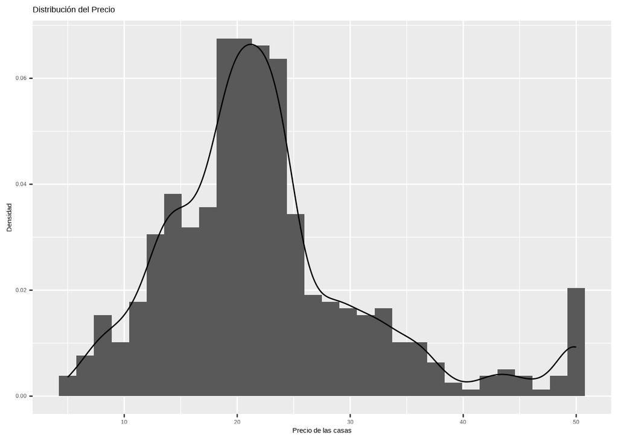

Figura 1. Distribución del precio de la vivienda

```r
Boston |>  ggplot(aes(x=medv)) + geom_histogram(aes(y=..density..))+ geom_density() + ggtitle("Distribución del Precio") + xlab("Precio de las casas") + ylab("Densidad")
```

Dada esta asimetría, quizás debamos considerar modelizar posteriormente esta variable transformada en logaritmos. La razón: se aprecia un comportamiento que puede modelizarse mejor de forma no lineal. También se puede nota una acumulación de valores en 50 mil dólares. Se puede observar en los resultados de `describe()` que ese valor exacto se repite varias veces, NO es producto de la discretización del gráfico en la que se acumulan varios valores diferentes en un intervalo en torno a 50; también debemos probar distintos anchos de intervalo como se ha discutido en clase.

También podemos representar gráficamente o en un tabla la única variable categórica que tenemos. La conclusión no es particularmente interesante: solo unas pocas zonas de la ciudad están cerca del río.

```r
Boston |>  count(chas) |>
  mutate(freq=n/sum(n)) |>
  kbl(col.names=c("Casa cercana al río","Número de casos", "Frecuencia"),
                  caption = "Tabla 1. Distribución de Casas según cercanía al río") |> kable_paper("hover")
```

Tabla 1. Distribución de Casas según cercanía al río

| Casa cercana al río | Número de casos | Frecuencia |
| --- | --- | --- |
| No | 471 | 0.93083 |
| Yes | 35 | 0.06917 |

En el caso de variables binarias las podemos representar de varias maneras: como una distribución o con una sola barra (NOTA: los gráficos siguientes son redundantes en esta caso, con uno de ellos sería más que suficiente en caso de considerar relevante esta información.)

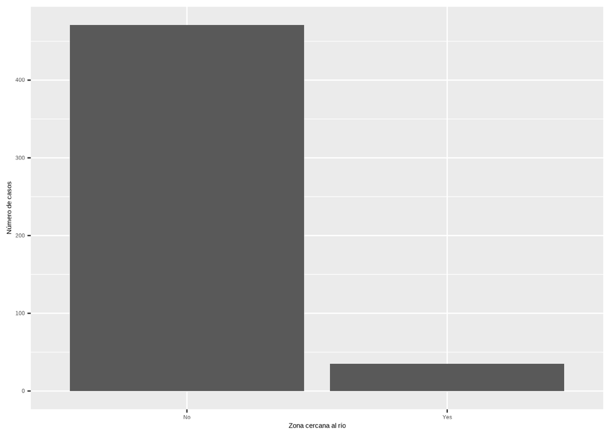

Figura 2. Distribución de la cercanía al río

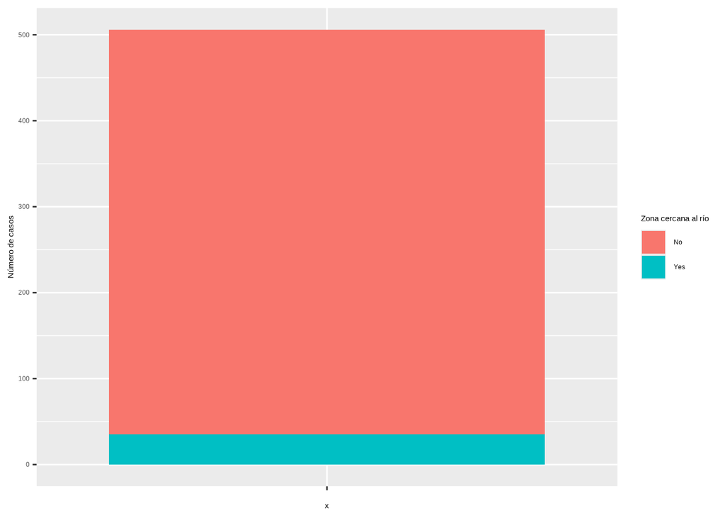

Figura 2. Distribución de la cercanía al río

```r
Boston |>  ggplot() + geom_bar(aes(x=chas)) +  xlab("Zona cercana al río") +ylab("Número de casos")

Boston |>  ggplot() + geom_bar(aes(x="",fill=chas)) + labs(fill="Zona cercana al río") +ylab("Número de casos")
```

También podemos mostrar algunas otras características interesantes mediante gráficos y/o tablas de estadísticos descriptivos. Algunas variables como el número de habitaciones tienen distribuciones bastante simétricas. Mientras que otras, como la edad o el porcentaje de población desfavorecida muestran claras asimetrías: hay una alta concentración de casas “viejas” y de zonas no desfavorecidas. NOTA: Recordad que habría que probar varios anchos de intervalos (*binwidth*) para asegurarnos de entender la forma de la distribución. También debéis poner nombres suficientemente descriptivos e informativos a los gráficos, los ejes, la leyenda, etc. (Quizás no es el caso en algunos de los que presento aquí).

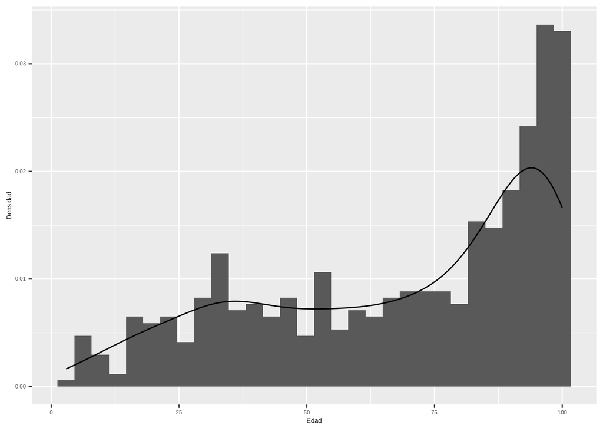

Figura 3. Distribuciones

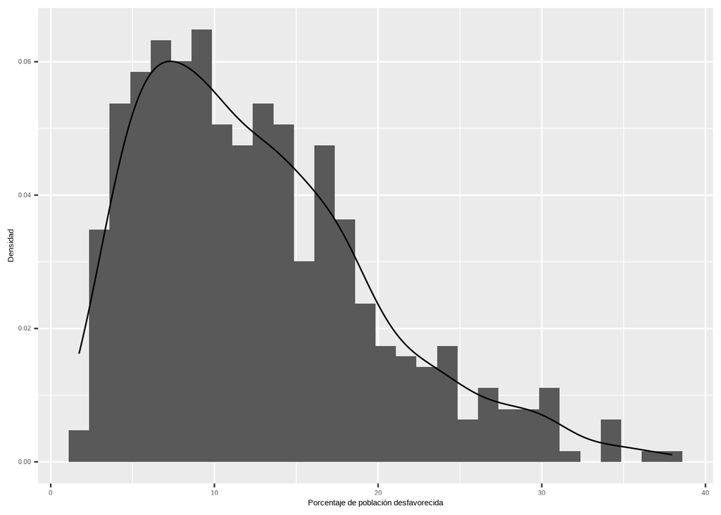

Figura 3. Distribuciones

```r
Boston |>  ggplot(aes(x=age)) + geom_histogram(aes(y=..density..))+ geom_density() + xlab("Edad") + ylab("Densidad")

Boston |>  ggplot(aes(x=lstat)) + geom_histogram(aes(y=..density..))+ geom_density() + xlab("Porcentaje de población desfavorecida") + ylab("Densidad")
```

Notad que en la variable edad nuevamente hay una concentración de valores en 100; en la salida `describe()` mostrada anteriormente, se aprecia mejor que ese valor exacto está en los datos originales, no resulta de que se agrupen valores en el gráfico.

El caso de la distancia a los centros de empleo es similar a las dos anteriores: una gran concentración en zonas bien conectadas, aunque una cola de zonas alejadas. Se podría omitir: no hay que mostrar gráficos o tablas de cada variable ni comentar necesariamente las características de la distribución de todas, solo de aquellas con rasgos interesante o relevantes.

Otra variable en principio relacionada, el índice de accesibilidad, muestra una distribución “poco continua”: además de un cúmulo de valores en la cola derecha, hay muchos huecos vacíos. Si probáis un transformación logarítmica, veréis que no cambia en esencia. Las variables con este forma en su distribución suelen ser candidatas a ser discretizadas.

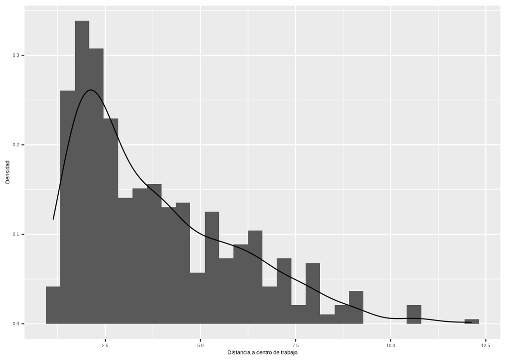

Figura 4. Distribuciones

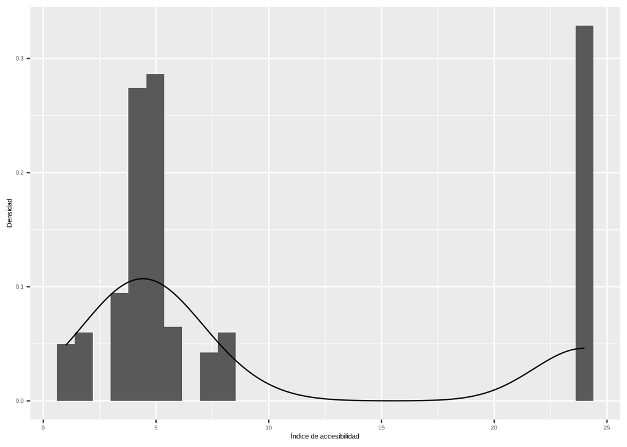

Figura 4. Distribuciones

```r
Boston |>  ggplot(aes(x=dis)) + geom_histogram(aes(y=..density..))+ geom_density() + xlab("Distancia a centro de trabajo") + ylab("Densidad")

Boston |>  ggplot(aes(x=rad)) + geom_histogram(aes(y=..density..))+ geom_density() + xlab("Índice de accesibilidad") + ylab("Densidad")
```

Algunas variables tienen distribuciones con características poco reseñables: unas con valores distribuidos de forma relativamente homogénea, otras dispersas, con concentraciones en valores aislados en medio o en los extremos de la distribución, pero no aportan mucho información (se podrían omitir). En este caso, quizás se podría notar una concentración de zonas con altos impuestos, muy diferenciadas del resto.

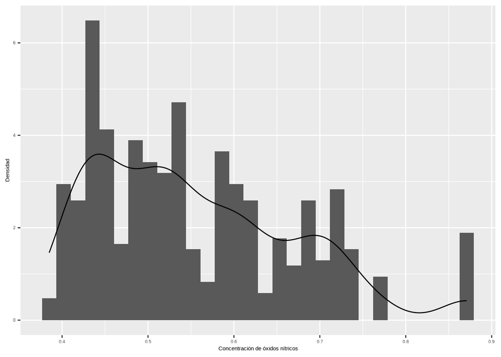

Figura 5. Distribuciones

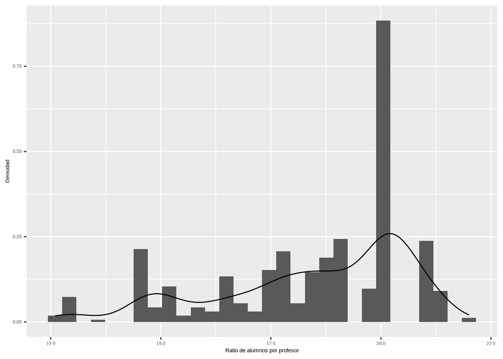

Figura 5. Distribuciones

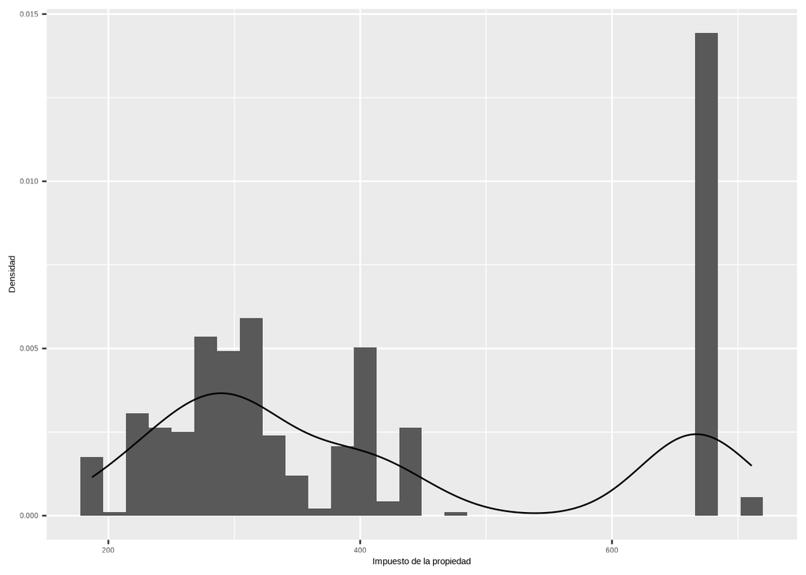

Figura 5. Distribuciones

```r
Boston |>  ggplot(aes(x=nox)) + geom_histogram(aes(y=..density..))+ geom_density() + xlab("Concentración de óxidos nítricos") + ylab("Densidad")

Boston |>  ggplot(aes(x=ptratio)) + geom_histogram(aes(y=..density..))+ geom_density() + xlab("Ratio de alumnos por profesor") + ylab("Densidad")

Boston |>  ggplot(aes(x=tax)) + geom_histogram(aes(y=..density..))+ geom_density() + xlab("Impuesto de la propiedad") + ylab("Densidad")
```

Algo más interesantes son algunas variables que muestran polaridad en sus valores o una excesiva acumulación en algunos. Por ejemplo, la criminalidad y el porcentaje de población de color tienen distribuciones muy asimétricas y, en el segundo caso, persiste incluso tras transformar en logaritmos.

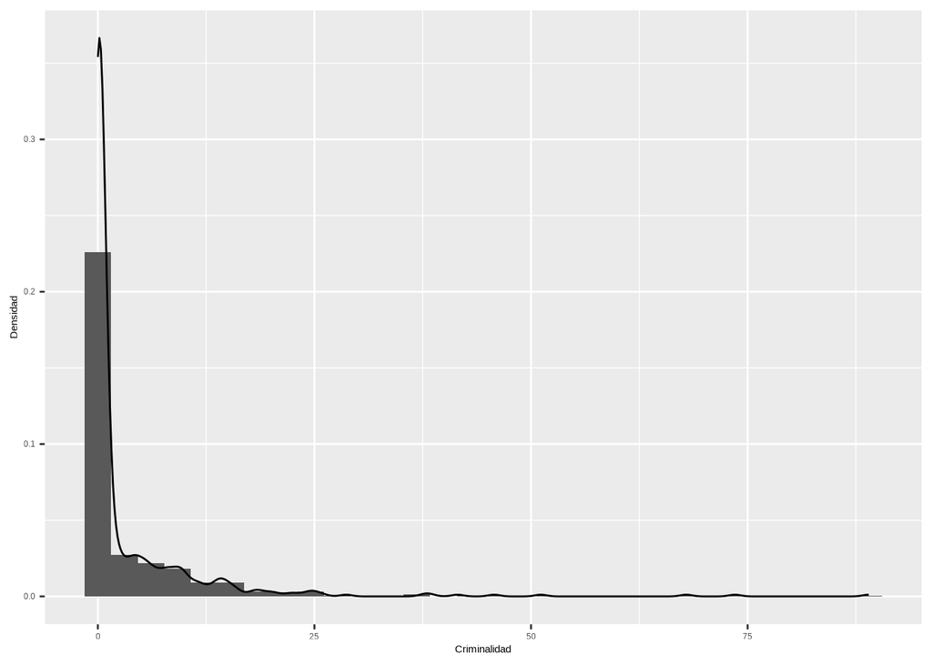

Figura 6a. Distribuciones

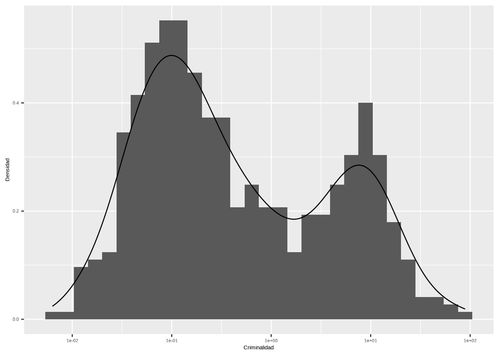

Figura 6a. Distribuciones

```r
Boston |>  ggplot(aes(x=crim)) + geom_histogram(aes(y=..density..))+ geom_density() + xlab("Criminalidad") + ylab("Densidad")
Boston |>  ggplot(aes(x=crim)) + geom_histogram(aes(y=..density..))+ geom_density() + xlab("Criminalidad") + ylab("Densidad") + scale_x_log10()
```

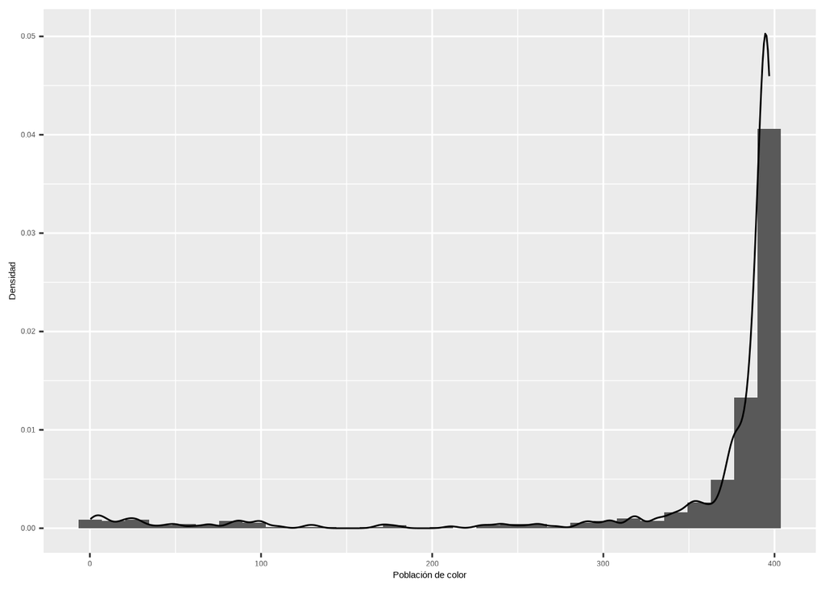

Figura 6b. Distribuciones

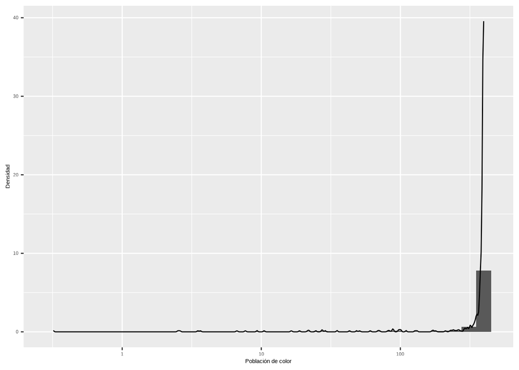

Figura 6b. Distribuciones

```r
Boston |>  ggplot(aes(x=b)) + geom_histogram(aes(y=..density..))+ geom_density() + xlab("Población de color") + ylab("Densidad")
Boston |>  ggplot(aes(x=b)) + geom_histogram(aes(y=..density..))+ geom_density() + xlab("Población de color") + ylab("Densidad") + scale_x_log10()
```

Estas variables y algunas otras anteriores son candidatas a ser discretizadas. La criminalidad, por ejemplo, no solo muestra una concentración en unos pocos valores, sino que una vez transformada en logaritmos se aprecian dos grupos diferenciados, como también pasaba con los impuestos. En el caso de la ratio de profesor/alumno también unos valores con gran concentración de frecuencia y muy pocos por encima de este por lo que podrían agruparse juntos. En el caso de la población de color, vemos que a partir del percentil 75, los valores son prácticamente iguales y antes del percentil 10 son mucho menores que en el resto de la distribución. En estos casos de variables con valores concentrados o infrecuentes y con saltos o huecos, no podemos decir que la variable que observamos en nuestra muestra tenga una apariencia de variable continua, aunque en principio lo sea. Por tanto, agrupar y discretizar es una buena opción. En particular, es más fácil identificar el efecto medio sobre el precio de la vivienda de un rango de valores (ej., zonas de baja criminalidad frente a alta) que el efecto de incrementar en un punto la variable (cuando en los datos no observamos valores con ese punto más). En otras palabras, vamos a modelizar efectos flexibles no lineales.

### MUY IMPORTANTE:

NO mostréis todos los gráficos o tablas que se os ocurran o solo porque los veáis aquí. ELEGID adecuadamente aquellos que consideréis más relevantes o interesantes y aporten información útil para responder a los objetivos planteados.

## Análisis de covariación

Empezamos analizando la relación entre nuestra variable de interés y la única variable categórica que tenemos inicialmente, para lo que podríamos presentar alguna (NO todas) de las siguientes figuras

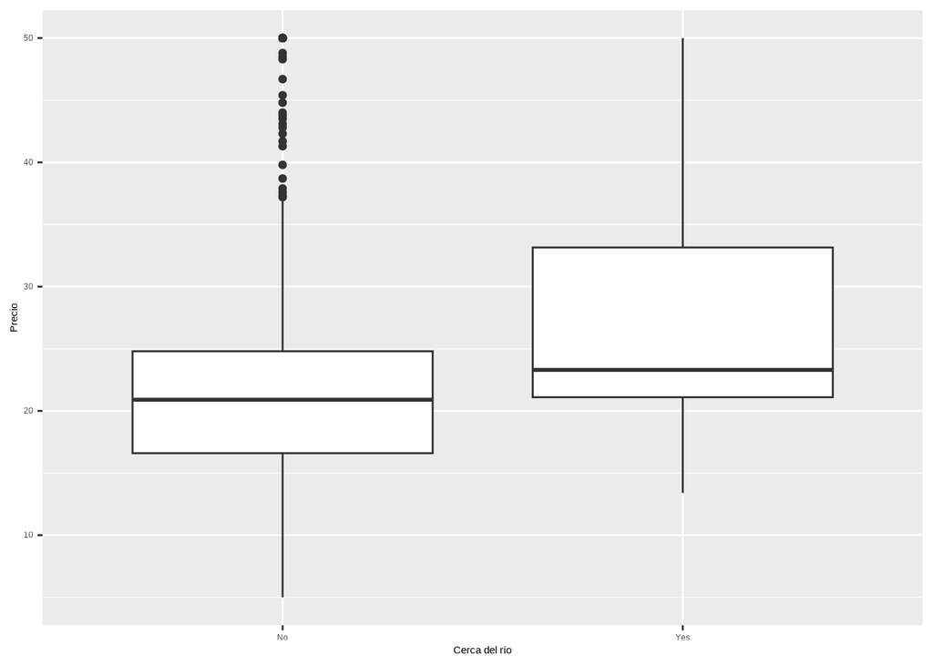

Figura 7a. Distribución del precio por cercanía al rio

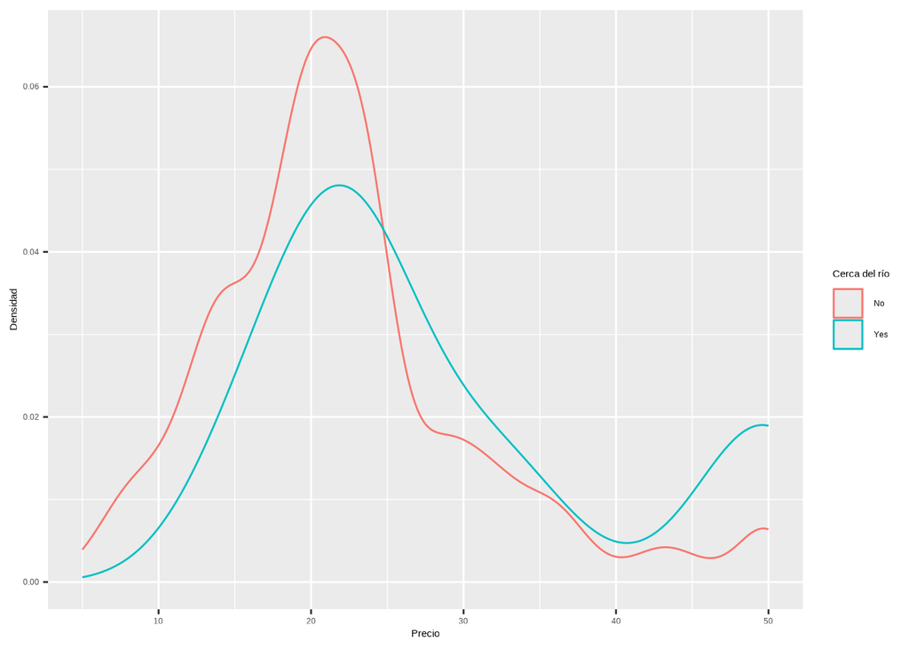

Figura 7a. Distribución del precio por cercanía al rio

```r
Boston |> ggplot(aes(y = medv, x = chas)) +  geom_boxplot() + ylab("Densidad") + xlab("Cerca del río") + ylab("Precio")
Boston |> ggplot(aes(x = medv)) + geom_density(mapping = aes(colour = chas)) + xlab("Precio") + ylab("Densidad")  + labs(color = "Cerca del río")
```

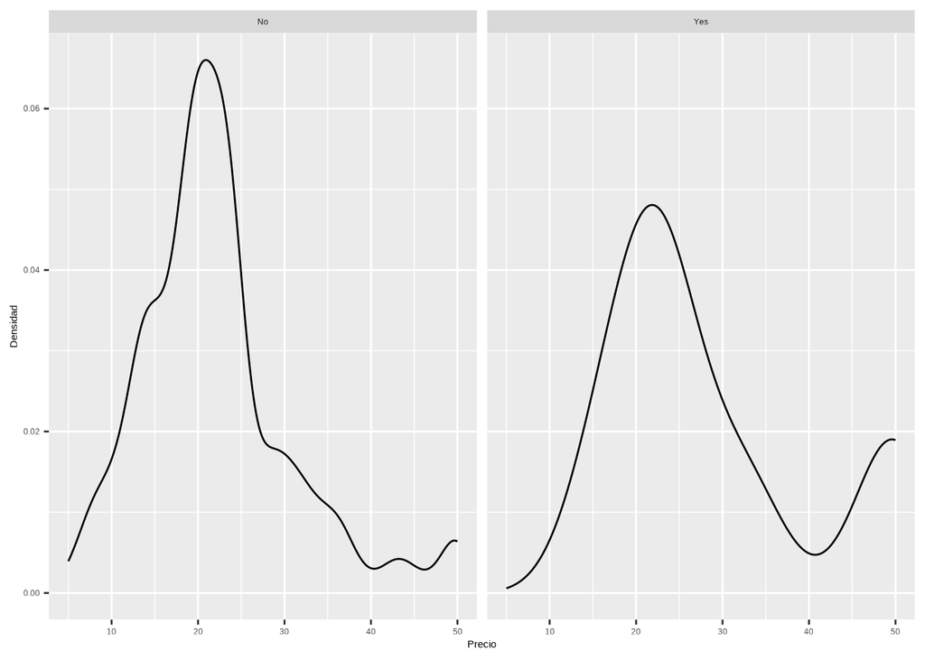

Figura 7b. Distribución del precio, según cercanía al rio

```r
Boston |> ggplot(aes(x = medv)) + geom_density() + facet_wrap(~chas) + ylab("Densidad")  + xlab("Precio")
```

```r
lm(data = Boston, medv ~ chas) |> broom::tidy() |>  kbl(digits = 2, caption = "Tabla 2a. Precio según cercanía al río") |> kable_paper("hover")
```

Tabla 2a. Precio según cercanía al río

| term | estimate | std.error | statistic | p.value |
| --- | --- | --- | --- | --- |
| (Intercept) | 22.09 | 0.42 | 52.9 | 0 |
| chasYes | 6.35 | 1.59 | 4.0 | 0 |

```r
Boston |> group_by(chas) |> describe(medv) |> select(described_variables:n, mean, se_mean) |>  kbl(digits = 2, caption = "Tabla 2b. Precio según cercanía al río") |> kable_paper("hover")
```

Tabla 2b. Precio según cercanía al río

| described_variables | chas | n | mean | se_mean |
| --- | --- | --- | --- | --- |
| medv | No | 471 | 22.09 | 0.41 |
| medv | Yes | 35 | 28.44 | 2.00 |

También podríamos analizar si la variable binaria de cercanía al río está relacionada. (NOTA: esto nuevamente es un código de ejemplo para hacer de forma fácil este proceso. NO es necesario que vosotros lo hagáis así.)

```r
vars <- c("crim", "zn", "indus", "nox", "rm", "age", "dis", "rad", "tax", "ptratio", "b", "lstat")

tabla <-list()
for (var in vars) {
  formula <- paste0(var," ~ chas")
  tabla[[var]] <- lm(data = Boston, formula) |> tidy() |> filter(term=="chasYes") |> select(estimate, p.value)
}

tabla |> bind_rows(.id="Variable")  |>  kbl(digits = 2, caption = "Tabla 2c. Diferencias en variable por cercanía al río") |> kable_paper("hover")
```

Tabla 2c. Diferencias en variable por cercanía al río

| Variable | estimate | p.value |
| --- | --- | --- |
| crim | -1.89 | 0.21 |
| zn | -3.92 | 0.34 |
| indus | 1.70 | 0.16 |
| nox | 0.04 | 0.04 |
| rm | 0.25 | 0.04 |
| age | 9.59 | 0.05 |
| dis | -0.82 | 0.03 |
| rad | -0.25 | 0.87 |
| tax | -23.61 | 0.42 |
| ptratio | -1.04 | 0.01 |
| b | 17.54 | 0.27 |
| lstat | -1.52 | 0.23 |

Vemos que las casas cercanas al rio son más antiguas, con más habitaciones, más cercanas al centro de trabajo, con más contaminación y mejores condiciones escolares.

A continuación podemos analizar rápidamente si las variables continuas están relacionadas con nuestra variable de interés, precio de la vivienda, y entre ellas. Lo podemos hacer mediante distintos análisis de correlación, en una tabla (excesivamente larga) o visualmente.

```r
Boston |> correlate() |>
  filter(as.integer(var1) > as.integer(var2)) |>
  kbl(digits = 2, caption = "Tabla 3. Correlaciones") |> kable_paper("hover")
```

[output not shown]

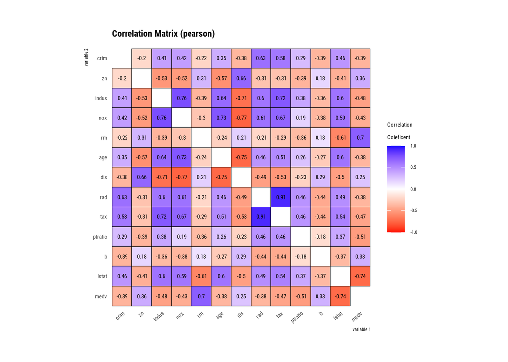

Figura 8. Correlaciones entre variables continuas

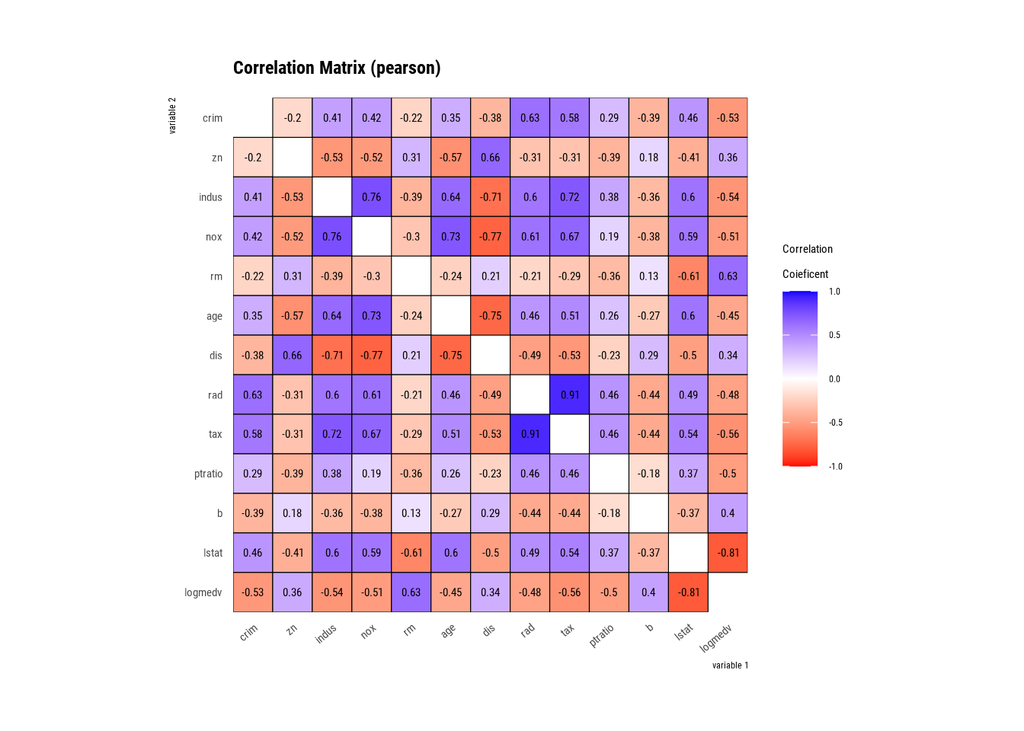

Figura 8. Correlaciones entre variables continuas

```r
Boston |> correlate() |> plot()

Boston |> mutate(logmedv=log(medv)) |> select(-medv) |> correlate() |> plot()
```

Hemos considerado la correlación tanto con el precio como con su logaritmo, dado lo discutido anteriormente. Sin embargo, apenas se aprecian diferencias.

Vemos que existe una fuerte correlación (positiva o negativa) entre el precio y varias variables que intuitivamente consideraríamos como importantes. El número de habitaciones tiene la correlación positiva más fuerte con el valor medio del precio de la vivienda, mientras que el porcentaje de la población desfavorecida y el número de alumnos por docente tienen una correlación negativa fuerte. También es evidente que las zonas más industriales y la contaminación están fuertemente correlacionados positivamente entre sí, puesto que los niveles de óxido nítrico tienden a aumentar con el aumento de las industrias. También vemos que las zonas con más población desfavorecida son las más industriales y contaminadas, con casas más antiguas y de menos habitaciones y con escuelas con un mayor ratio de alumnos por profesor. Debemos recordar esto de cara a la especificación de los modelos de regresión lineal.

Sin embargo, esto no considera posibles relaciones no lineales. Para ello vamos a representar varios gráficos de dispersión y un ajuste no lineal. Nuevamente, en vuestro trabajo no mostraréis necesariamente todos estos gráficos sino una selección después de haberlos vistos.

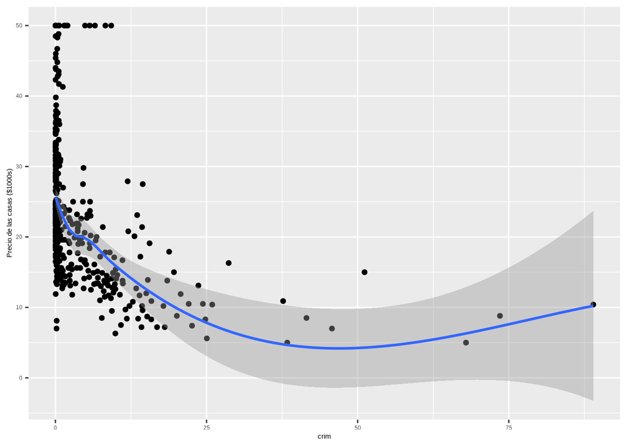

Figura 9a. Gráficos de dispersión

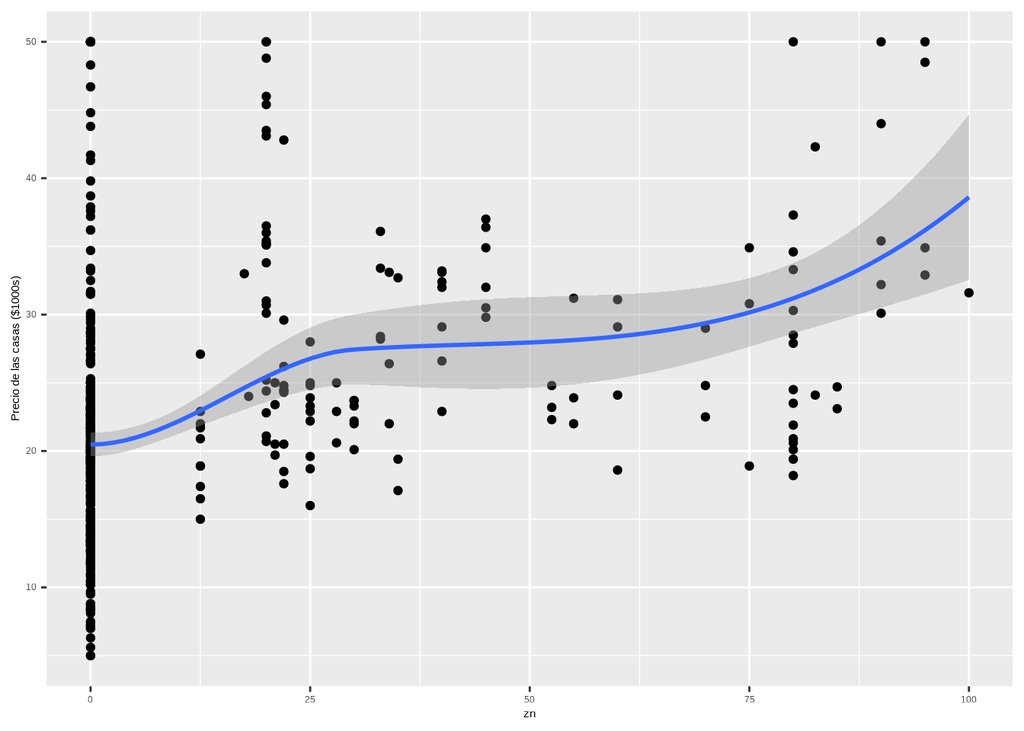

Figura 9a. Gráficos de dispersión

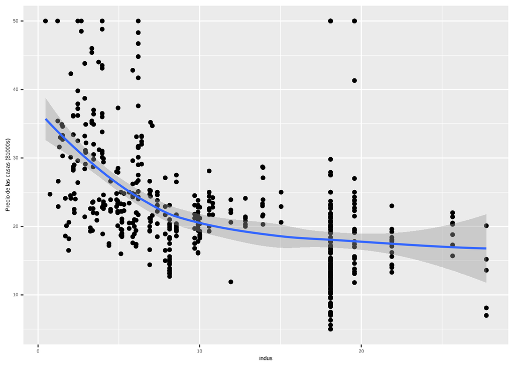

Figura 9a. Gráficos de dispersión

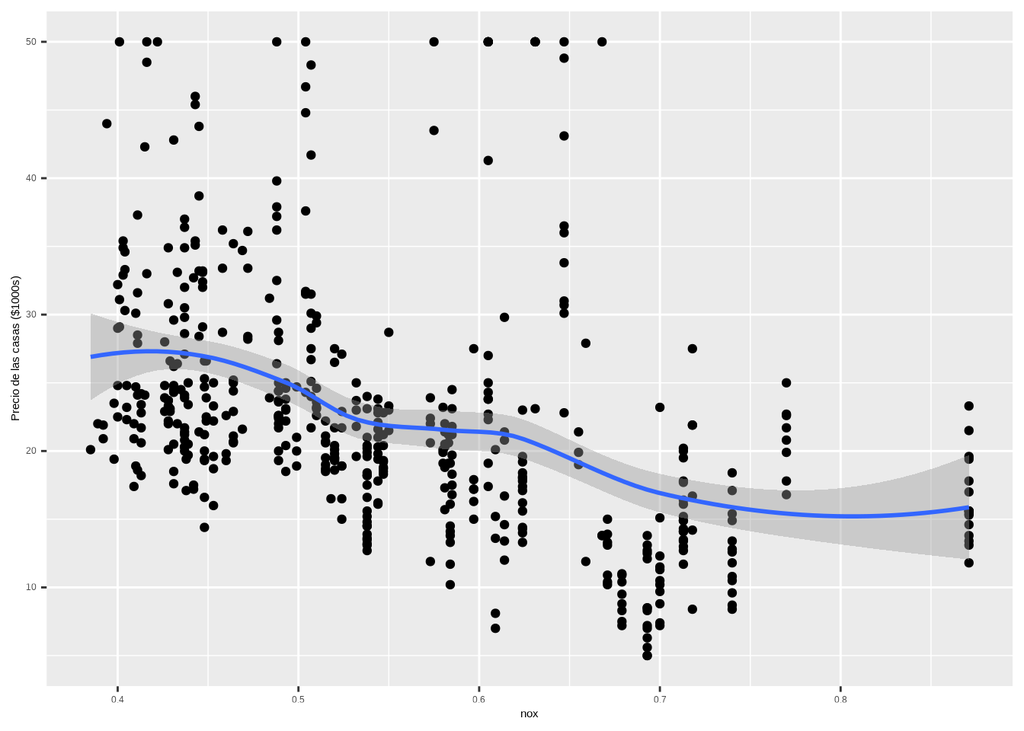

Figura 9a. Gráficos de dispersión

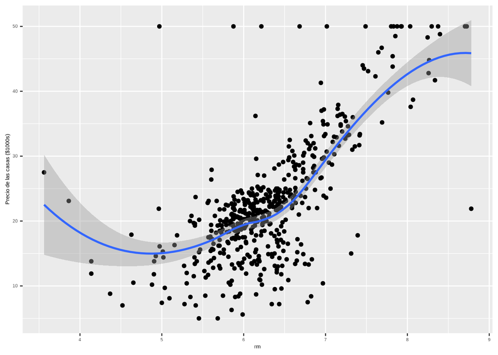

Figura 9a. Gráficos de dispersión

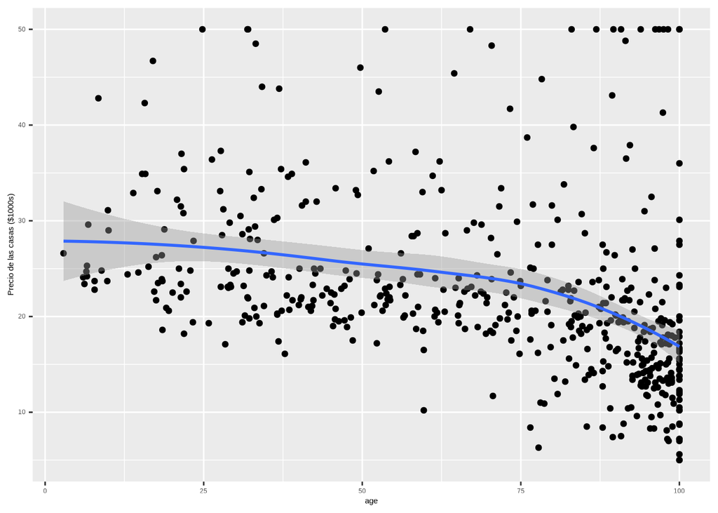

Figura 9a. Gráficos de dispersión

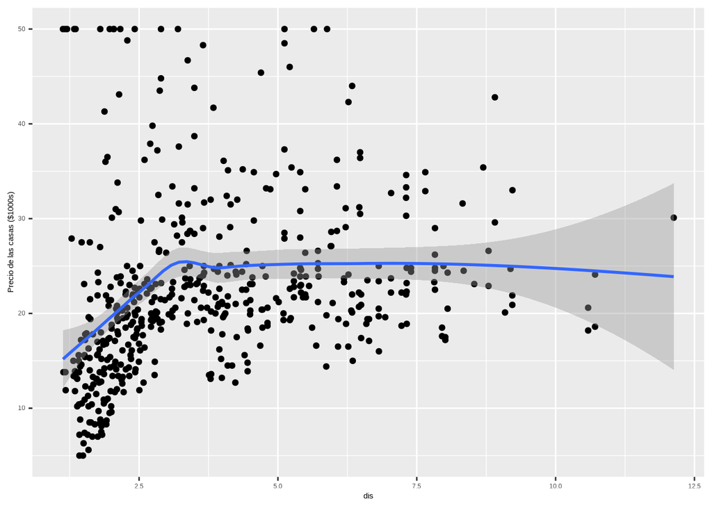

Figura 9a. Gráficos de dispersión

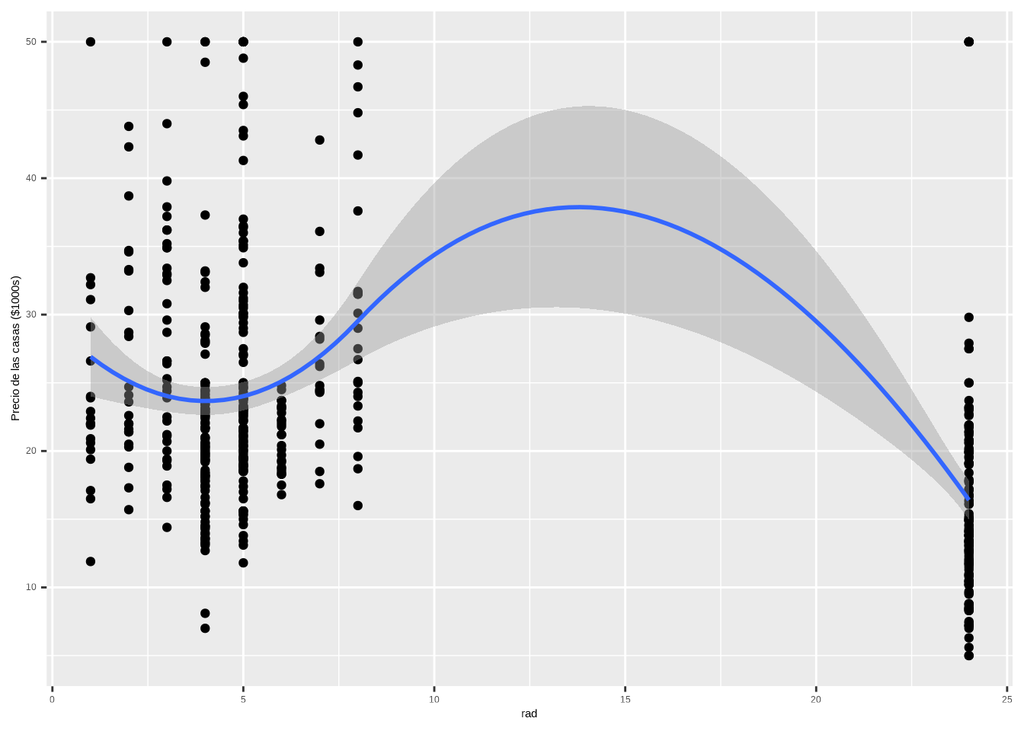

Figura 9a. Gráficos de dispersión

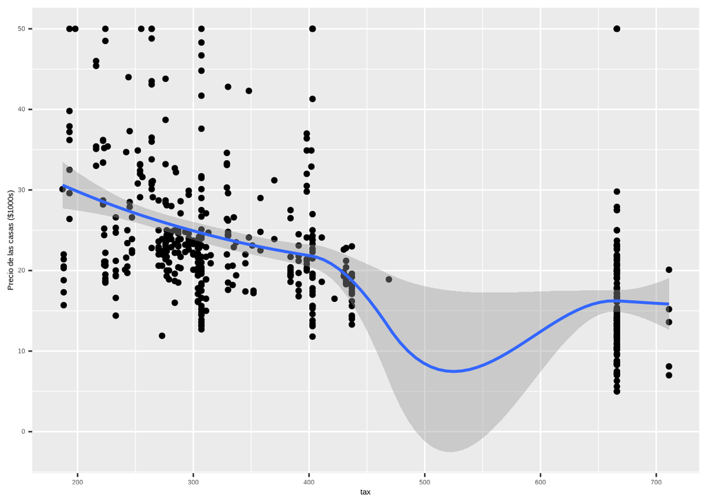

Figura 9a. Gráficos de dispersión

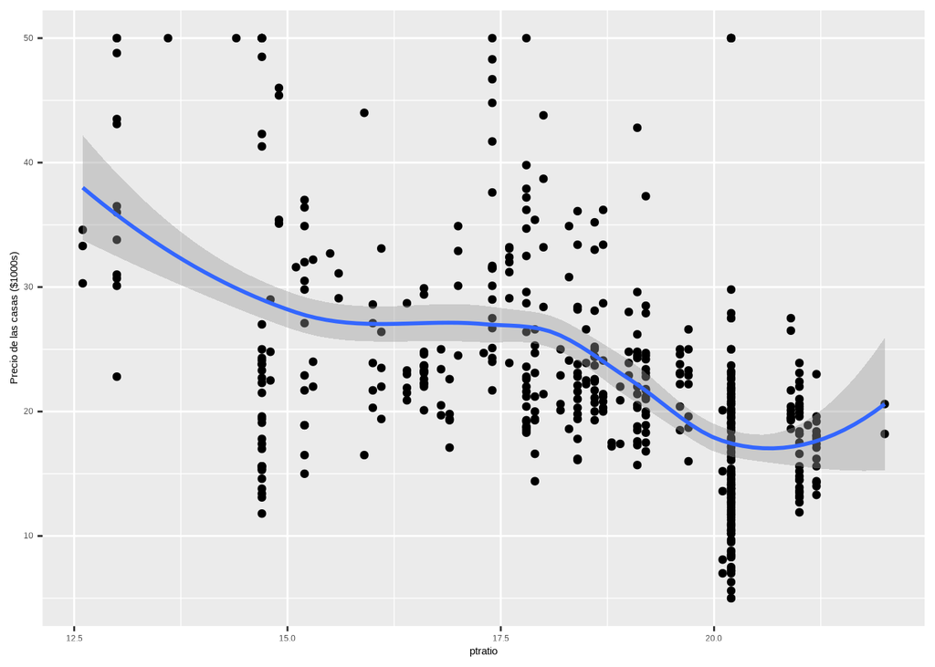

Figura 9a. Gráficos de dispersión

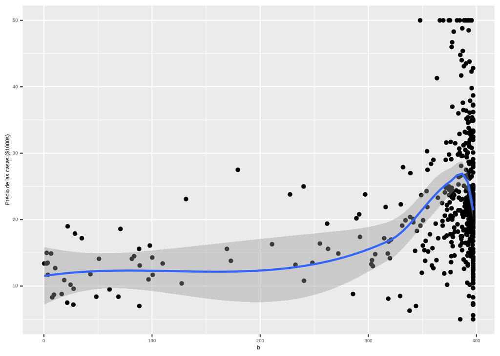

Figura 9a. Gráficos de dispersión

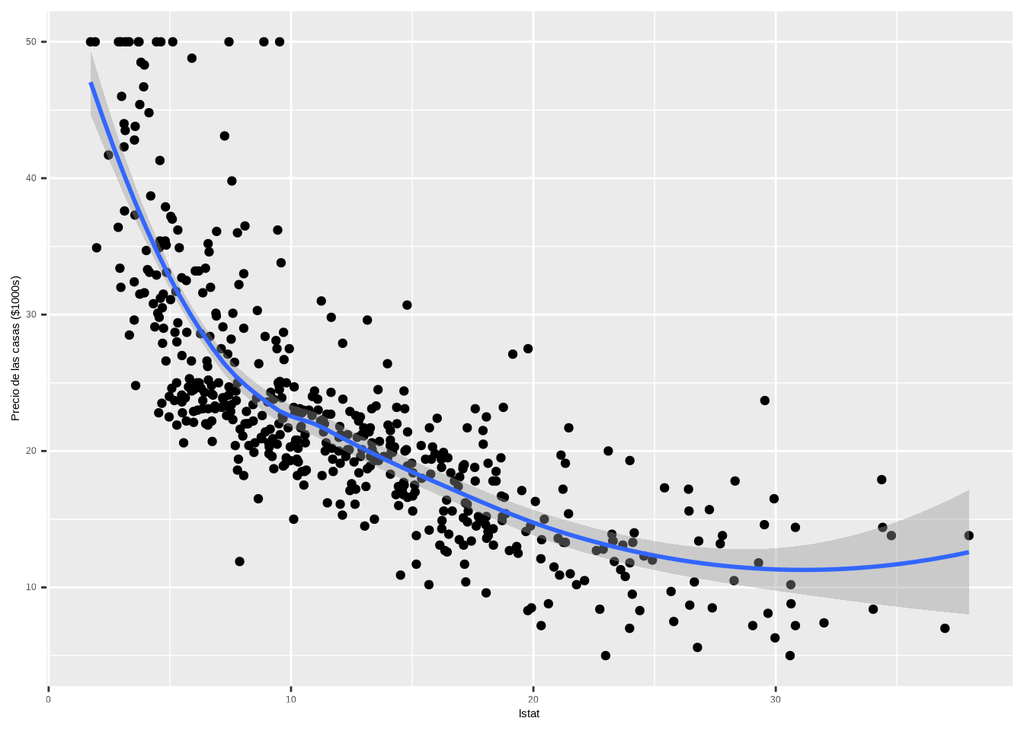

Figura 9a. Gráficos de dispersión

```r
vars <- c("crim", "zn", "indus", "nox", "rm", "age", "dis", "rad", "tax", "ptratio", "b", "lstat")

for (v in vars){
  graf <- Boston |>
            ggplot(aes_string(x = v, y = "medv")) +
            geom_point() +  geom_smooth() +
            labs(x = v, y = "Precio de las casas ($1000s)")
  print(graf)
}
```